# worksheet01_walker

Reuben Walker

15 April 2024

## t-test

```r
#Sample Vector
num_samples <- 10
#Take a sample of random continues values between [-1,1] with .001 steps (number of steps 2000+1 for -1:1)
cont_distribution <- sample(seq(-1, 1, length.out = 2001), size = num_samples)

#Take a sample of a student-t distribution with parameter nu = 1
#To do this, we use the rt function (pseudo-random numbers from t-distribution) with nu (degrees of freedom) = 1
t_distribution <- rt(num_samples, df=1)


#Take a sample of random discrete values either -1 or 1, replace=TRUE so we can keep sampling
disc_distribution <- sample(c(-1,1), size=num_samples, replace=TRUE)

#Let's just do it for n=5 and plot the histogram of the p values
df = data.frame(continuous=double(),
                t=double(),
                discrete=double()
                )

for (j in 1:10000) {
  num_samples = 5
  cont_distribution_1 <- sample(seq(-1, 1, length.out = 2001), size = num_samples)
  cont_distribution_2 <- sample(seq(-1, 1, length.out = 2001), size = num_samples)
  #Pull the p-value from the t-test
  p_cont <- t.test(cont_distribution_1, cont_distribution_2)$p.value

  t_distribution_1 <- rt(num_samples, df=1)
  t_distribution_2 <- rt(num_samples, df=1)
  p_t <- t.test(t_distribution_1, t_distribution_2)$p.value

  disc_distribution_1 <- sample(c(-1,1), size=num_samples, replace=TRUE)
  disc_distribution_2 <- sample(c(-1,1), size=num_samples, replace=TRUE)
  #The t.test returns an error when the two values are constant
  #This is because there is a variance term in the denominator
  #Check for null variance
  null_variance <- ((var(disc_distribution_1) == 0) & (var(disc_distribution_2) == 0))
  p_disc <- ifelse(null_variance, NaN, t.test(disc_distribution_1, disc_distribution_2)$p.value)

  #Append a row in the dataframe
  df <- rbind(df, data.frame(continuous=p_cont, t=p_t, discrete=p_disc))
}
```

## Histograms for continuous, student-t, and discrete distributions

#Bin width of 0.05, so the furthest left bar is p-value less than 0.05

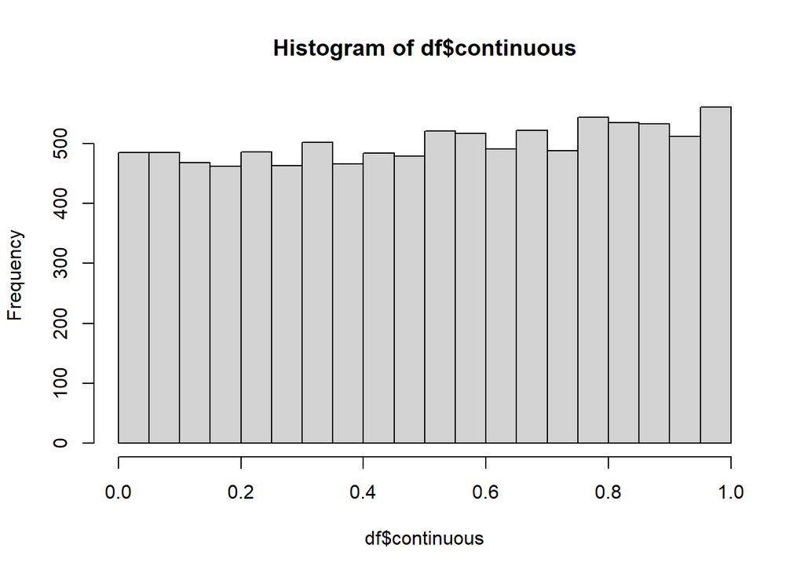

```r
hist(df$continuous)#, breaks = seq(from=0, to=1, by=0.05))
```

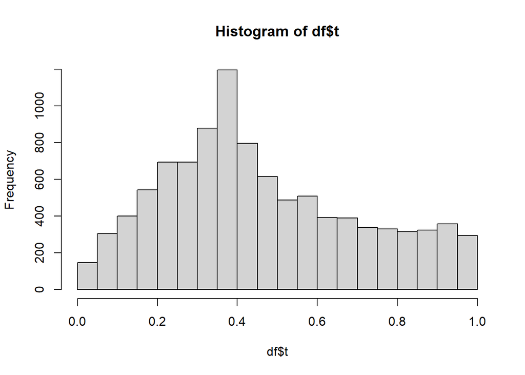

```r
hist(df$t)#, breaks = seq(from=0, to=1, by=0.05))
```

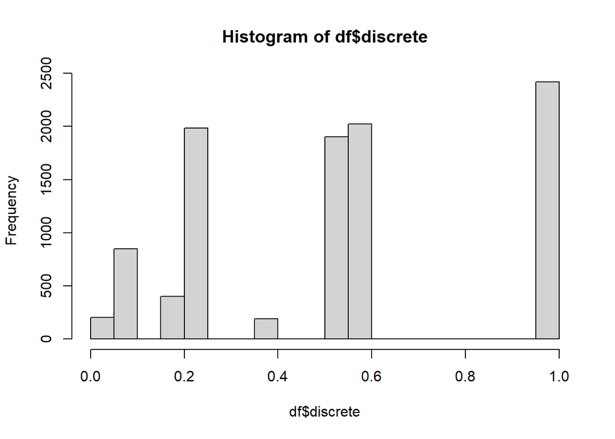

```r
hist(df$discrete)#, breaks = seq(from=0, to=1, by=0.05))
```

```r
#How many is that for each?
cont_result_0 <- sum(df$continuous <0.05)/length(df$continuous)
cont_result_0
```

```
## [1] 0.0485
```

```r
#0.04

t_result_0 <- sum(df$t <0.05)/length(df$t)
t_result_0
```

```
## [1] 0.0147
```

```r
#0.01

#Non-NaN subset
disc_result_0 <- sum(na.omit(df$discrete) <0.05)/length(na.omit(df$discrete))
disc_result_0
```

```
## [1] 0.02016453
```

```r
#0.02

#Now let's repeat is for all sample sizes
sampleNumbers <- c(5,10,20,50,100)
cont_result <- c()
t_result <- c()
disc_result <- c()
for (x in sampleNumbers) {
  df = data.frame(continuous=double(),
                t=double(),
                discrete=double()
                )
  for (j in 1:10000) {
    num_samples = x
    cont_distribution_1 <- sample(seq(-1, 1, length.out = 20001), size = num_samples)
    cont_distribution_2 <- sample(seq(-1, 1, length.out = 20001), size = num_samples)
    #Pull the p-value from the t-test
    p_cont = t.test(cont_distribution_1, cont_distribution_2)$p.value

    t_distribution_1 <- rt(num_samples, df=1)
    t_distribution_2 <- rt(num_samples, df=1)
    p_t = t.test(t_distribution_1, t_distribution_2)$p.value

    disc_distribution_1 <- sample(c(-1,1), size=num_samples, replace=TRUE)
    disc_distribution_2 <- sample(c(-1,1), size=num_samples, replace=TRUE)
    #The lack of variation is much less likely with increasing sample size
    null_variance <- ((var(disc_distribution_1) == 0) & (var(disc_distribution_2) == 0))
    p_disc <- ifelse(null_variance, NaN, t.test(disc_distribution_1, disc_distribution_2)$p.value)


    #Append a row in the dataframe
    df <- rbind(df, data.frame(continuous=p_cont, t=p_t, discrete=p_disc))
  }
  cont_perc <- sum(df$continuous < 0.05)/length(df$continuous)
  cont_result <- append(cont_result, cont_perc)

  t_perc <- sum(df$t < 0.05)/length(df$t)
  t_result <- append(t_result, t_perc)

  disc_perc <- sum(na.omit(df$discrete) < 0.05)/length(na.omit(df$discrete))
  disc_result <- append(disc_result, disc_perc)
}

#So more or less regardless of sample size, they're staying the same?
library(ggplot2)
library(tidyverse)
#plot(sampleNumbers, cont_result, col='green', ylim=c(0,0.1), main='Probability of p<0.05 (continuous)')#, type='l'
#plot(sampleNumbers, t_result, type='l', col='blue', ylim=c(0,0.1))
#plot(sampleNumbers, disc_result, type='l', col='red', ylim=c(0,1))

#And all together?
plot_df <- data.frame(samplesize=sampleNumbers,
                      continuous=cont_result,
                      t=t_result,
                      discrete=disc_result)

library(tidyverse)
plot_df2 <- plot_df %>%
  select(samplesize, continuous, t, discrete) %>%
  gather(key = "variable", value = "value", -samplesize)
head(plot_df2)
```

```
##   samplesize   variable  value
## 1          5 continuous 0.0481
## 2         10 continuous 0.0527
## 3         20 continuous 0.0495
## 4         50 continuous 0.0505
## 5        100 continuous 0.0471
## 6          5          t 0.0147
```

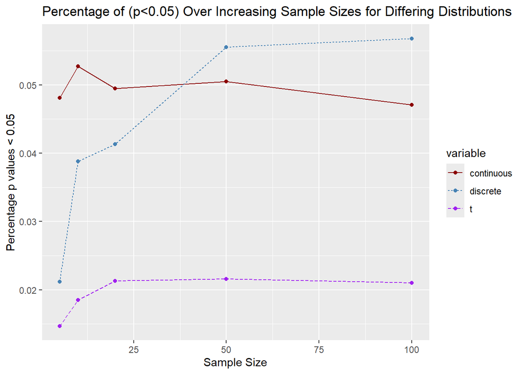

```r
plot_f <-ggplot(plot_df2, aes(x = samplesize, y = value)) +
  geom_line(aes(color = variable, linetype = variable)) +
  geom_point(aes(color = variable)) +
  scale_color_manual(values = c("darkred", "steelblue", "purple"))
plot_f + ggtitle("Percentage of (p<0.05) Over Increasing Sample Sizes for Differing Distributions") + xlab("Sample Size") + ylab("Percentage p values < 0.05")
```

#3 FALSE: p-values are used to calculate the probability of the null hypothesis given the data. Why: p-values are a measure of surprise and caculated under the assumption that the null hypothesis is true.

TRUE: The significance level alpha is the probability of rejecting the null hypothesis when it is true.

FALSE: The Central Limit Theorem only holds if the population from which we are sampling is normally distributed. Why: The Central Limit Theorem states that for large sample sizes, the sample mean is approximately normally distributed, regardless of the distribution.

FALSE: As the sample size gets larger, the standard error of the sampling distribution of the sample mean gets larger as well. Why: The calculation of the standard error includes the root of sample size in the denominator and should decrease with increased sample size.

FALSE: The statistical power of a hypothesis test it the probability of not rejecting the null when H1 is true. Why: Statistical power is the probability that “one will correctly reject the null hypothesis” if the alternative hypothesis is true. (The alternative hypothesis being that the null hypothesis is false).

FALSE: The statistical power of a hypothesis test is the probability of rejecting H1 when H1 is true. Why: Statistical power is the probability that “one will correctly reject the null hypothesis” if the alternative hypothesis is true. (The alternative hypothesis being that the null hypothesis is false).